# Visualización en R

Leon Berdichevsky

14 de agosto de 2018

# Visualización

Para la visulización de datos, en este curso utilizaremos el paquete para graficar ggplot2. Podemos cargar ggplot2 directamente o podemos cargar el paquete para análsis de datos tydiverse que contiene al paquete ggplot2:

```r
library(tidyverse) # Cargamos el paquete en nuestra sesión
```

Cubriremos los siguientes puntos:

- Gráficas de dispersión.
- Distintos tipos de gráficas.
- Páneles de gráficas.

### Gráficas de dispersión

Usaremos la base de datos `mpg` que se incluye en R básico; se puede encontrar información de esta base de datos tecleando `?mpg`.

```r
#?mpg
glimpse(mpg)
```

```
## Observations: 234
## Variables: 11
## $ manufacturer <chr> "audi", "audi", "audi", "audi", "audi", "audi", "...
## $ model        <chr> "a4", "a4", "a4", "a4", "a4", "a4", "a4", "a4 qua...
## $ displ        <dbl> 1.8, 1.8, 2.0, 2.0, 2.8, 2.8, 3.1, 1.8, 1.8, 2.0,...
## $ year         <int> 1999, 1999, 2008, 2008, 1999, 1999, 2008, 1999, 1...
## $ cyl          <int> 4, 4, 4, 4, 6, 6, 6, 4, 4, 4, 4, 6, 6, 6, 6, 6, 6...
## $ trans        <chr> "auto(l5)", "manual(m5)", "manual(m6)", "auto(av)...
## $ drv          <chr> "f", "f", "f", "f", "f", "f", "f", "4", "4", "4",...
## $ cty          <int> 18, 21, 20, 21, 16, 18, 18, 18, 16, 20, 19, 15, 1...
## $ hwy          <int> 29, 29, 31, 30, 26, 26, 27, 26, 25, 28, 27, 25, 2...
## $ fl           <chr> "p", "p", "p", "p", "p", "p", "p", "p", "p", "p",...
## $ class        <chr> "compact", "compact", "compact", "compact", "comp...
```

Para graficar, utilizaremos la función ggplot del paquete ggplot2. Para entender la *estructura de capas* de la función ggplot, consideremos una gráfica de dispersión simple:

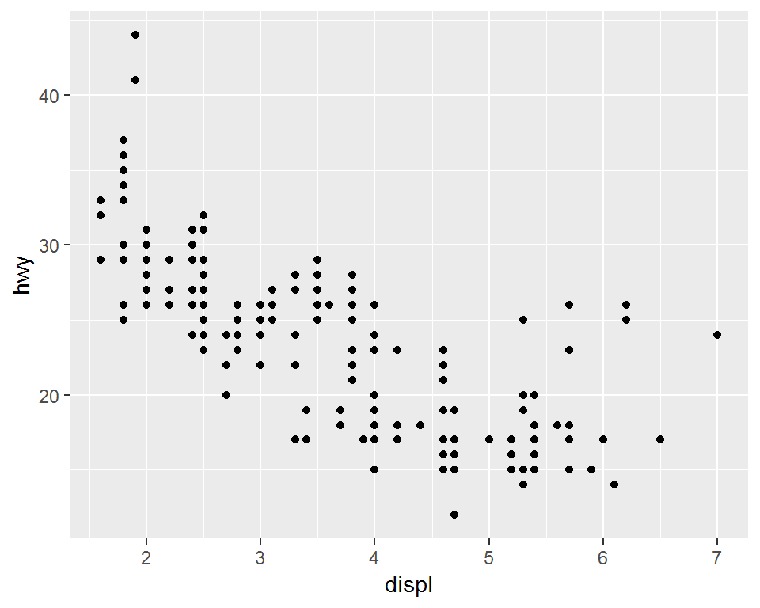

```r
ggplot(data = mpg) +
  geom_point(mapping = aes(x = displ, y = hwy))
```

La estructura del código es como sigue:

- En ggplot2 se inicia una gráfica con la instrucción `ggplot()`.
- Debemos especificar explicitamente que base de datos usamos, este es el primer argumento en la función ggplot.
- Una vez que creamos la base añadimos *capas*. La primera capa esta dada por una función *geométrica* `geom_tipodegrafica()`.
- Dentro de `aes()` escribimos las variables que queremos graficar y el atributo de la gráfica al que queremos mapearlas.
- Es posible agregar otros atributos a la gráfica utilizando más capas.

En el ejemplo, la función `geom_point()` añade una capa de puntos. Hay muchas funciones *geométricas* incluídas en ggplot2: `geom_line()`, `geom_boxplot()`, `geom_histogram`, etc. Cada una acepta distintos argumentos para mapear las variables en los datos a características estéticas de la gráfica. En el ejemplo de arriba mapeamos la variable `displ` al eje x y la variable `hwy` al eje y.

La función `geom_point()` nos permite representar más variables usando la forma, color y/o tamaño del punto. Esta flexibilidad nos permite entender o descubrir patrones más interesantes en los datos.

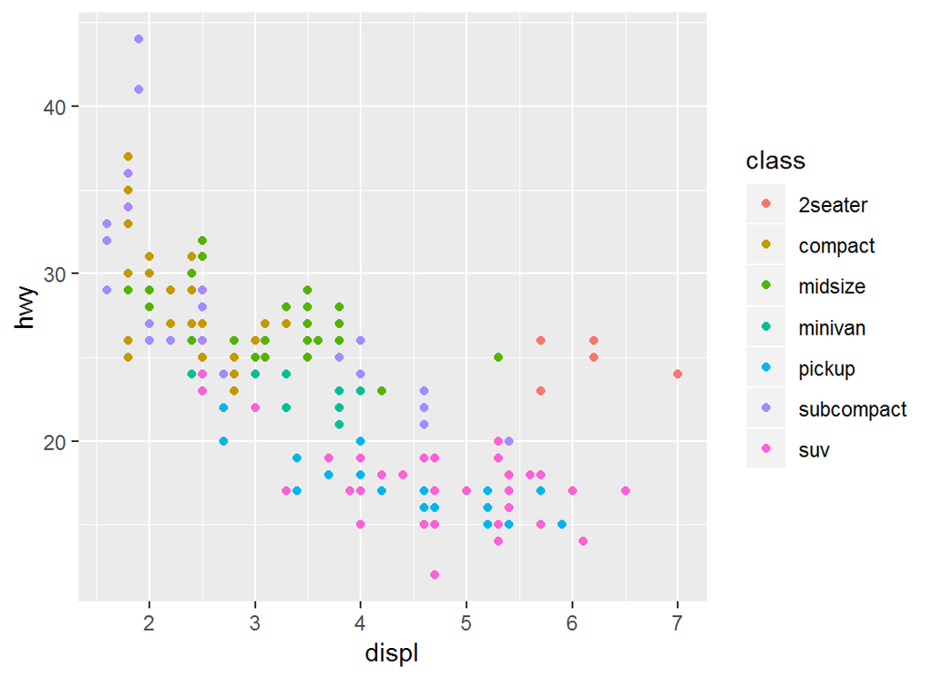

```r
ggplot(mpg) +
  geom_point(aes(x = displ, y = hwy, color = class))
```

**Ejercicio:** Experimenta con los *aesthetics* color (color), tamaño (size) y forma (shape). ¿Qué diferencia hay entre las variables categóricas y las continuas? ¿Qué ocurre cuando combinas varios *aesthetics*?

El mapeo de las propiedades estéticas se denomina escalamiento y depende del tipo de variable. Las variables discretas (por ejemplo, género, escolaridad, país, etc.) se mapean a distintas escalas que las variables continuas (variables numéricas como por ejemplo, edad, estatura, etc.). Los *defaults* para algunos atributos son (estos se pueden modificar):

|  | Discreta | Continua |
| --- | --- | --- |
| Color (`color`) | Arcoiris de colores | Gradiente de colores |
| Tamaño (`size`) | Escala discreta de tamaños | Mapeo lineal entre el área y el valor |
| Forma (`shape`) | Distintas formas | No aplica |
| Transparencia (`alpha`) | No aplica | Mapeo lineal a la transparencia |

### Distintos tipos de gráficas

Los `geom`’s controlan el tipo de gráfica:

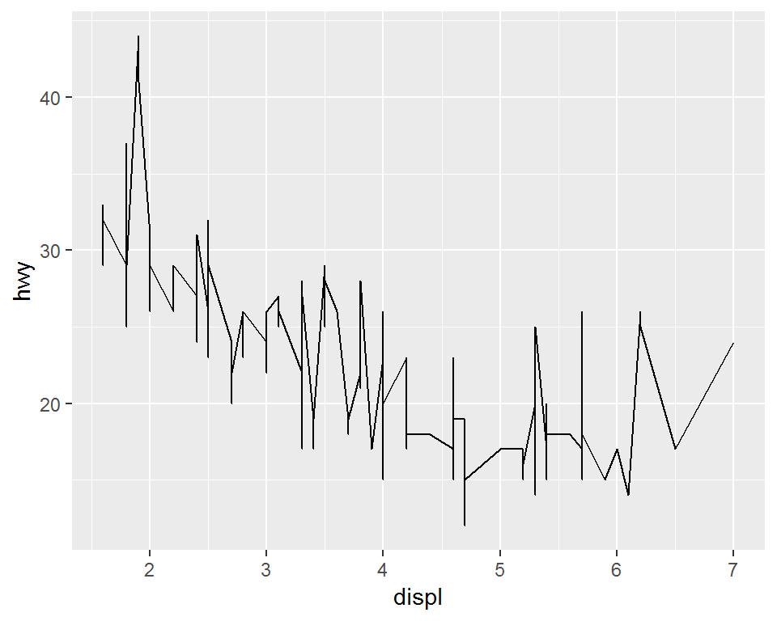

```r
p <- ggplot(mpg, aes(x = displ, y = hwy))
p + geom_line() # en este caso no es una buena gráfica
```

**Ejercicio:** ¿Cuál de las siguientes gráficas es más apropiada? ¿Por qué?

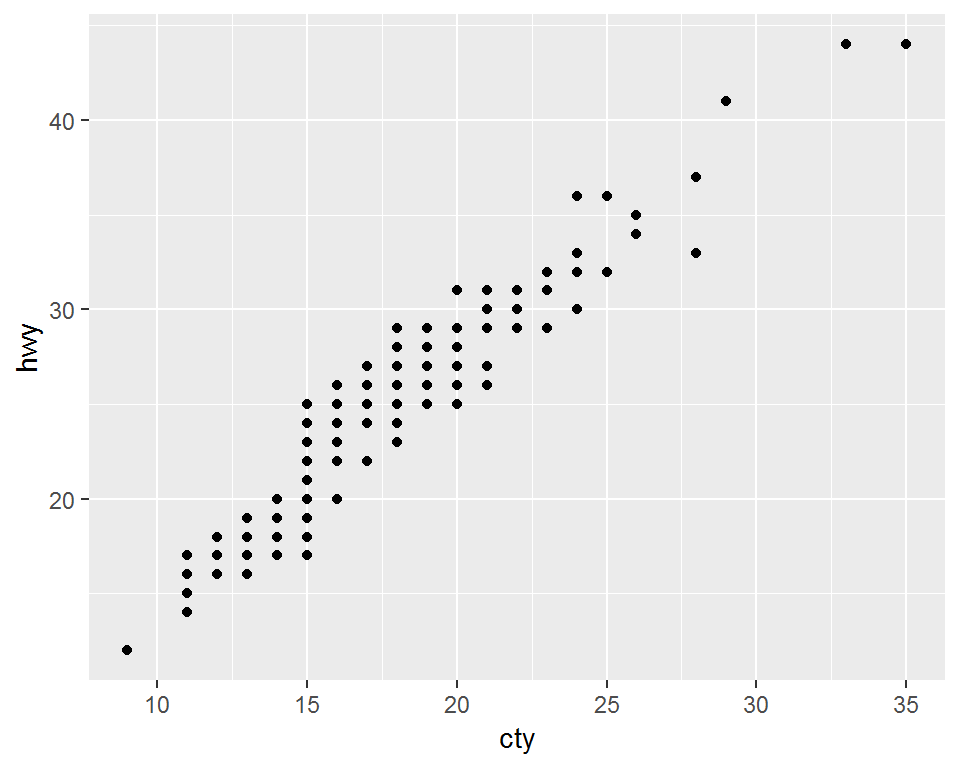

```r
p <- ggplot(mpg, aes(x = cty, y = hwy))
p + geom_point()
```

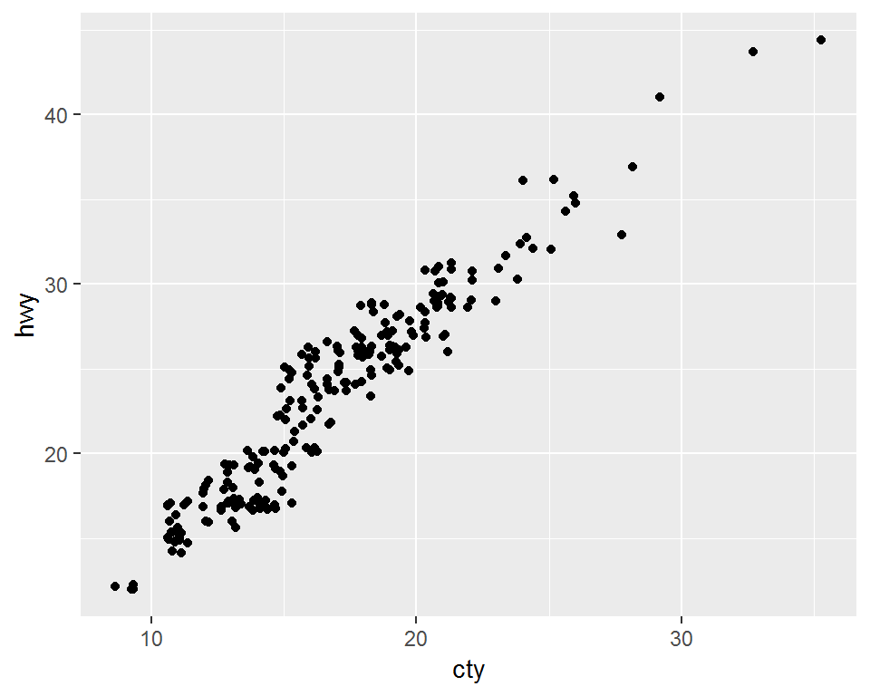

```r
p + geom_jitter()
```

**Pregunta:** ¿Cómo podemos mejorar la siguiente gráfica?

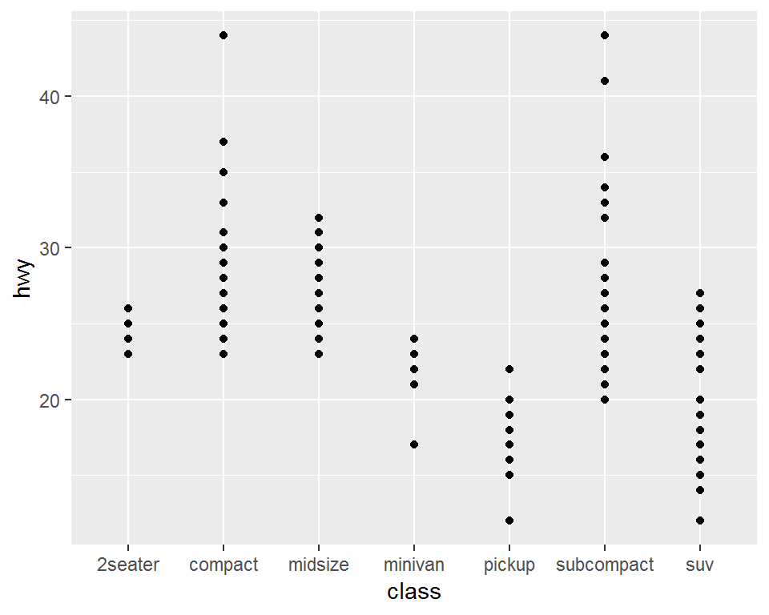

```r
ggplot(mpg, aes(x = class, y = hwy)) +
  geom_point()
```

**Respuesta:** Intentemos reordenar los niveles de la variable clase:

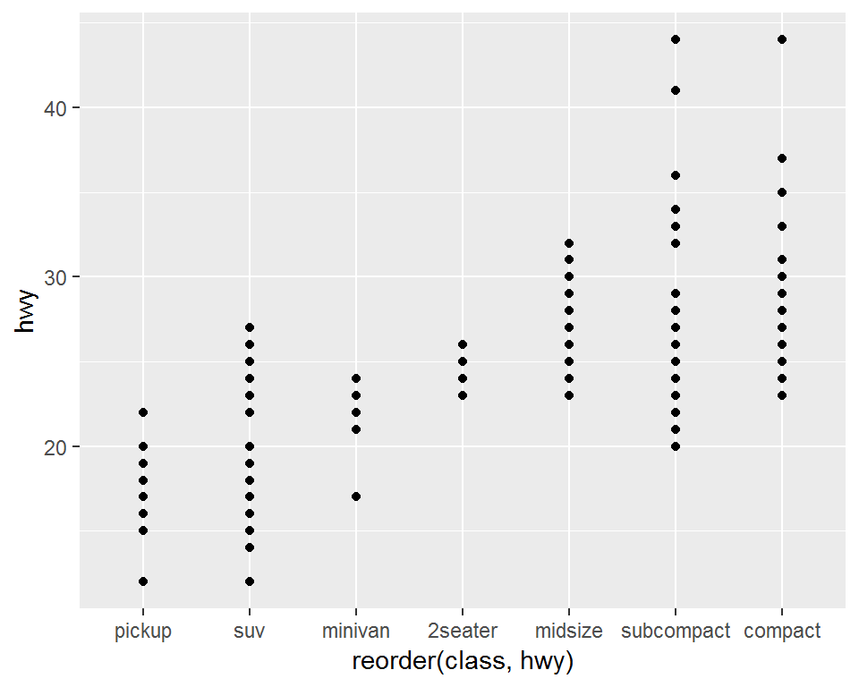

```r
ggplot(mpg, aes(x = reorder(class, hwy), y = hwy)) +
    geom_point()
```

Podemos probar otros `geom`s

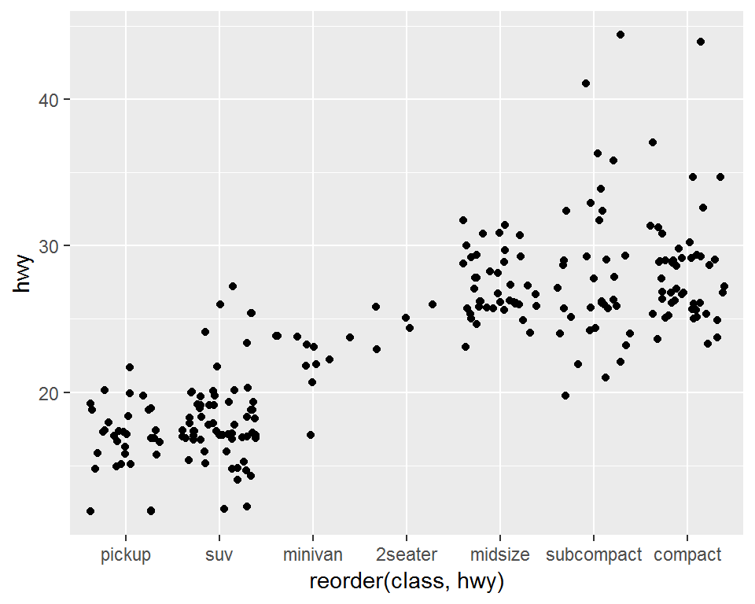

```r
ggplot(mpg, aes(x = reorder(class, hwy), y = hwy)) +
    geom_jitter()
```

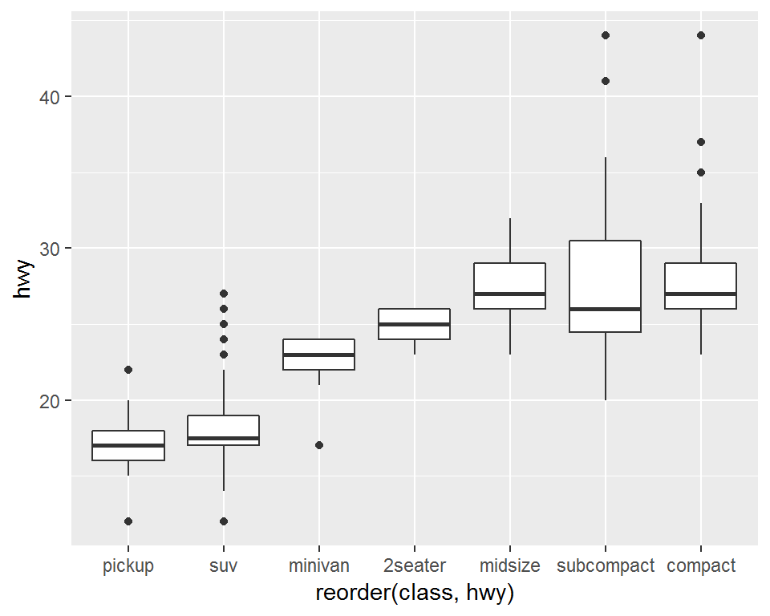

```r
ggplot(mpg, aes(x = reorder(class, hwy), y = hwy)) +
    geom_boxplot()
```

También podemos usar más de un `geom`:

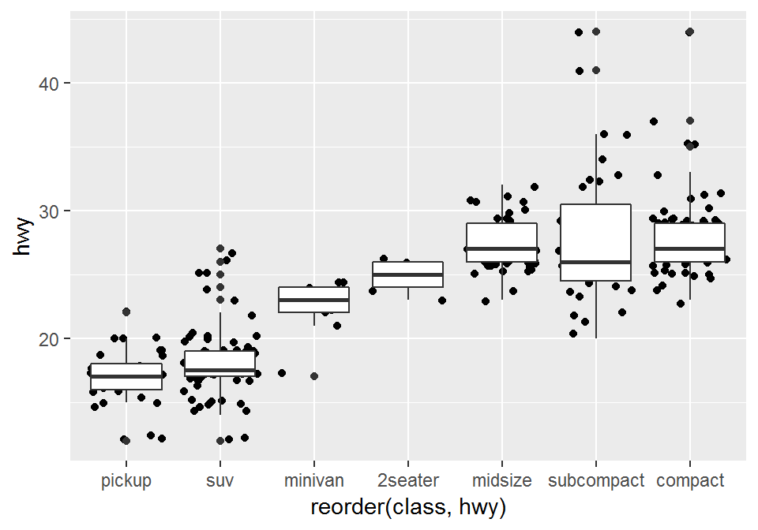

```r
ggplot(mpg, aes(x = reorder(class, hwy), y = hwy)) +
    geom_jitter() +
    geom_boxplot()
```

**Ejercicio:** Lee la ayuda de *reorder* y repite las gráficas anteriores ordenando por la mediana de *hwy*. ¿Cómo harías para graficar los puntos encima de las cajas de boxplot?

### Páneles de Gráficas

Veamos ahora como hacer páneles de gráficas; la idea es hacer varios múltiplos de una gráfica donde cada múltiplo representa un subconjunto de los datos. Se trata de una práctica muy útil para explorar relaciones condicionales.

En ggplot podemos usar la función `facet\_wrap()` para hacer páneles dividiendo los datos de acuerdo a las categorías de una sola variable:

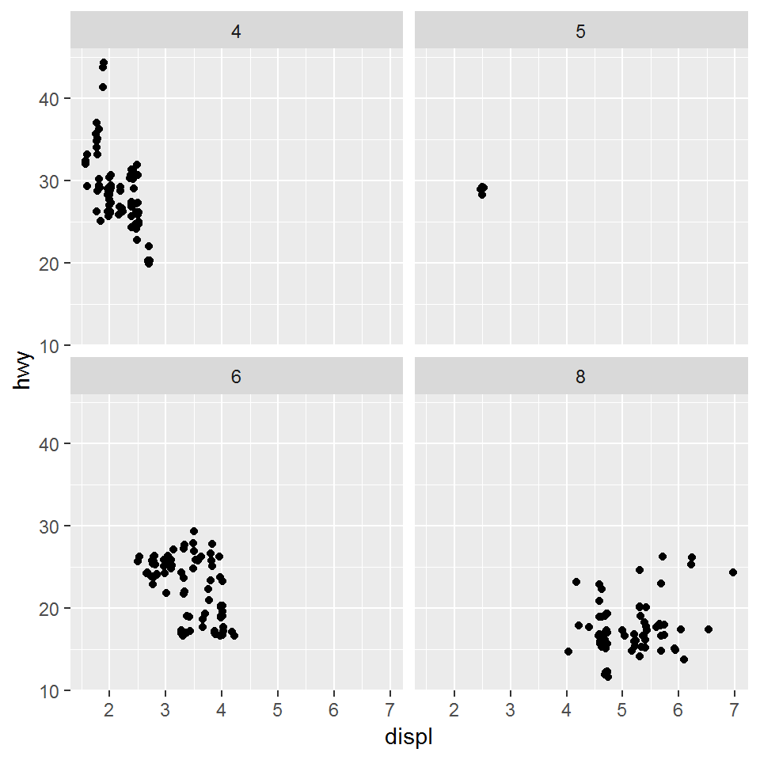

```r
ggplot(mpg, aes(x = displ, y = hwy)) +
  geom_jitter() +
  facet_wrap(~ cyl)
```

También podemos hacer una cuadrícula de 2 dimensiones usando `facet\_grid(filas~columnas)`:

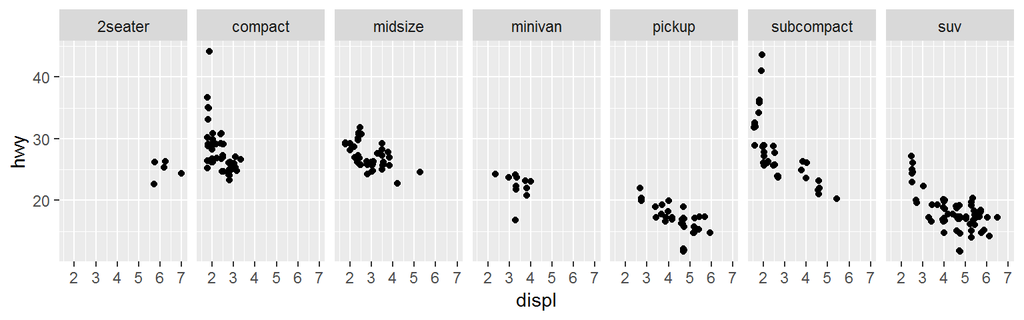

```r
ggplot(mpg, aes(x = displ, y = hwy)) +
  geom_jitter() +
  facet_grid(.~ class)
```

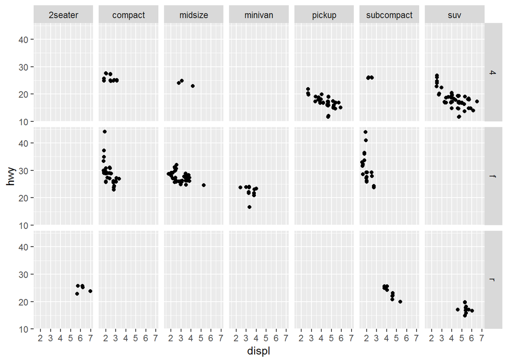

```r
ggplot(mpg, aes(x = displ, y = hwy)) +
  geom_jitter() +
  facet_grid(drv ~ class)
```

Los páneles pueden ser muy útiles para entender relaciones en nuestros datos.

Consideremos la base de datos `airquality` de R básico,

```r
glimpse(airquality)
```

```
## Observations: 153
## Variables: 6
## $ Ozone   <int> 41, 36, 12, 18, NA, 28, 23, 19, 8, NA, 7, 16, 11, 14, ...
## $ Solar.R <int> 190, 118, 149, 313, NA, NA, 299, 99, 19, 194, NA, 256,...
## $ Wind    <dbl> 7.4, 8.0, 12.6, 11.5, 14.3, 14.9, 8.6, 13.8, 20.1, 8.6...
## $ Temp    <int> 67, 72, 74, 62, 56, 66, 65, 59, 61, 69, 74, 69, 66, 68...
## $ Month   <int> 5, 5, 5, 5, 5, 5, 5, 5, 5, 5, 5, 5, 5, 5, 5, 5, 5, 5, ...
## $ Day     <int> 1, 2, 3, 4, 5, 6, 7, 8, 9, 10, 11, 12, 13, 14, 15, 16,...
```

```r
head(airquality)
```

```
##   Ozone Solar.R Wind Temp Month Day
## 1    41     190  7.4   67     5   1
## 2    36     118  8.0   72     5   2
## 3    12     149 12.6   74     5   3
## 4    18     313 11.5   62     5   4
## 5    NA      NA 14.3   56     5   5
## 6    28      NA 14.9   66     5   6
```

```r
str(airquality)
```

```
## 'data.frame':    153 obs. of  6 variables:
##  $ Ozone  : int  41 36 12 18 NA 28 23 19 8 NA ...
##  $ Solar.R: int  190 118 149 313 NA NA 299 99 19 194 ...
##  $ Wind   : num  7.4 8 12.6 11.5 14.3 14.9 8.6 13.8 20.1 8.6 ...
##  $ Temp   : int  67 72 74 62 56 66 65 59 61 69 ...
##  $ Month  : int  5 5 5 5 5 5 5 5 5 5 ...
##  $ Day    : int  1 2 3 4 5 6 7 8 9 10 ...
```

En la siguiente gráfica es difícil entender si existe una relación entre radiación solar y ozono:

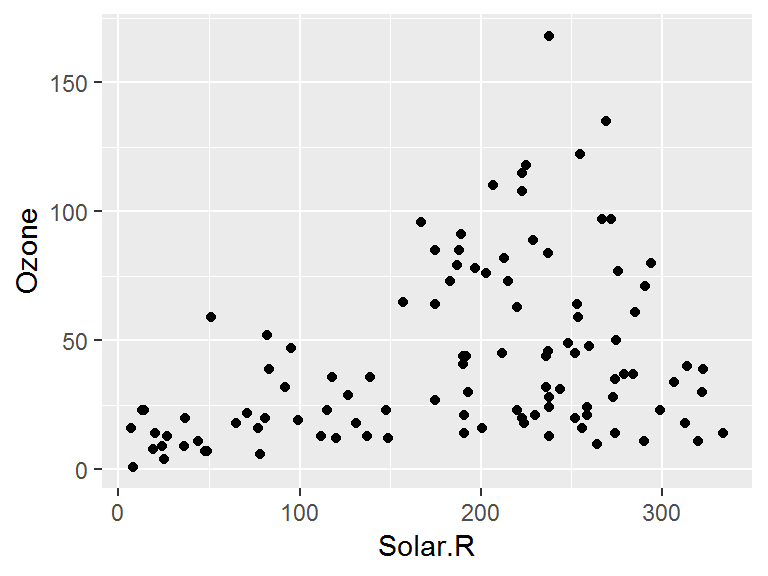

```r
data(airquality)
ggplot(airquality, aes(x = Solar.R, y = Ozone)) +
  geom_point()
```

Veamos que ocurre si realizamos páneles separando por velocidad del viento. Para ello utilizamos la instrucción `cut2` del paquete `Himsc` para transformar esta última variable en categórica:

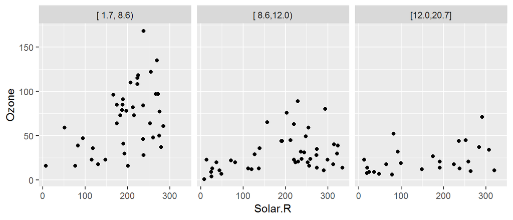

```r
#install.packages("Hmisc")
library(Hmisc)
airquality$Wind.cat <- cut2(airquality$Wind, g = 3)
ggplot(airquality, aes(x = Solar.R, y = Ozone)) +
  geom_point() +
  facet_wrap(~ Wind.cat)
```

Podemos agregar un suavizador (`loess`) para ver mejor la relación de las variables en cada panel:

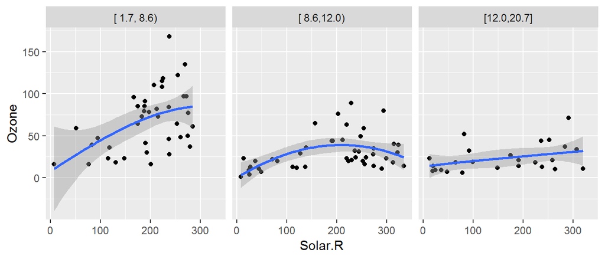

```r
ggplot(airquality, aes(x = Solar.R, y = Ozone)) +
  geom_point() +
  facet_wrap(~ Wind.cat) +
  geom_smooth(span = 3)
```

**Ejercicio:** Escribe algunas preguntas que se puedan contestar con estos datos.

En ocasiones es necesario realizar transformaciones u obtener subconjuntos de los datos para poder responder preguntas de nuestro interés.

Consideremos ahora la base de datos `babynames` del paquete con el mismo nombre:

```r
library(babynames)
glimpse(babynames)
```

```
## Observations: 1,858,689
## Variables: 5
## $ year <dbl> 1880, 1880, 1880, 1880, 1880, 1880, 1880, 1880, 1880, 188...
## $ sex  <chr> "F", "F", "F", "F", "F", "F", "F", "F", "F", "F", "F", "F...
## $ name <chr> "Mary", "Anna", "Emma", "Elizabeth", "Minnie", "Margaret"...
## $ n    <int> 7065, 2604, 2003, 1939, 1746, 1578, 1472, 1414, 1320, 128...
## $ prop <dbl> 0.072384329, 0.026679234, 0.020521700, 0.019865989, 0.017...
```

Supongamos que queremos ver la tendencia del nombre “John”; para ello debemos generar un subconjunto de la base de datos:

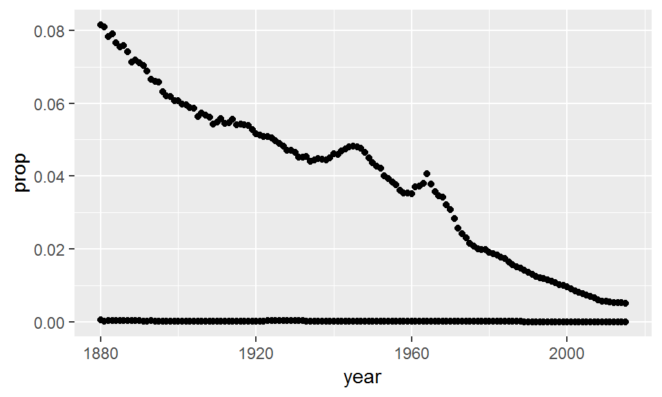

```r
babynames_John <- babynames[babynames$name == "John", ]
ggplot(babynames_John, aes(x = year, y = prop)) +
  geom_point()
```

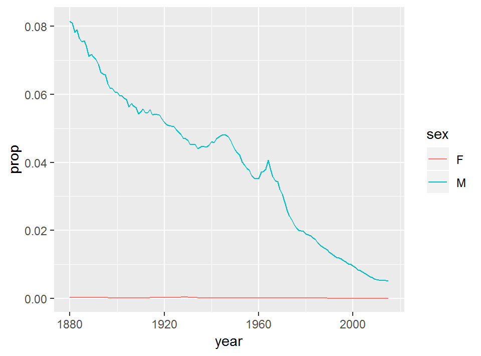

```r
ggplot(babynames_John, aes(x = year, y = prop, color = sex)) +
  geom_line()
```

La preparación de los datos es un aspecto muy importante del análisis y suele ser la fase que lleva más tiempo. Es por ello que el siguiente tema se enfocará en herramientas para hacer transformaciones de manera eficiente.

**Tarea:** Explora la base de datos gapminder. Estos datos están incluidos en el paquete del mismo nombre; para acceder a ellos basta con cargar el paquete:

```r
# install.packages("gapminder")
library(gapminder)
gapminder
```

```
## # A tibble: 1,704 x 6
##    country     continent  year lifeExp      pop gdpPercap
##    <fct>       <fct>     <int>   <dbl>    <int>     <dbl>
##  1 Afghanistan Asia       1952    28.8  8425333      779.
##  2 Afghanistan Asia       1957    30.3  9240934      821.
##  3 Afghanistan Asia       1962    32.0 10267083      853.
##  4 Afghanistan Asia       1967    34.0 11537966      836.
##  5 Afghanistan Asia       1972    36.1 13079460      740.
##  6 Afghanistan Asia       1977    38.4 14880372      786.
##  7 Afghanistan Asia       1982    39.9 12881816      978.
##  8 Afghanistan Asia       1987    40.8 13867957      852.
##  9 Afghanistan Asia       1992    41.7 16317921      649.
## 10 Afghanistan Asia       1997    41.8 22227415      635.
## # ... with 1,694 more rows
```

Realiza al menos 3 gráficas y explica las relaciones que encuentres. Debes usar lo que revisamos en estas notas (al menos una de las gráficas debe ser de un pánel de gráficas).

### Recursos

- Una muy buena primera referencia para Visualización son las notas **Introducción a la visualización de datos** de Felipe González, y las referencias incluidas en dichas notas.
- Google, stackoverflow.
- Para aprender más de ggplot pueden ver la documentación con ejemplos en la página de [ggplot2](http://ggplot2.tidyverse.org).
- Otro recurso muy útil es el [acordeón de ggplot](https://www.rstudio.com/wp-content/uploads/2015/04/ggplot2-spanish.pdf).